[figure not shown]

# CARS Tutorial

CARS Team

# Outline

- Tutorial preparation
- CARS context
- 3D photogrammetry basics
- CARS high level design
- CARS quickstart
- CARS CLI examples
- CARS Step by step framework manipulation

# Tutorial preparation

## Preparation

Prerequisites:

```
python >= 3.8
python-venv or virtualenv
gcc
web access
```

## Cars install from pypi

Follow CARS install: https://cars.readthedocs.io/en/latest/install.html

VLFEAT install:

```
git clone https://github.com/CNES/vlfeat.git
cd vlfeat && make && cd ..
export CFLAGS="-I$PWD/vlfeat"
export LDFLAGS="-L$PWD/vlfeat/bin/glnxa64"
export LD_LIBRARY_PATH="$PWD/vlfeat/bin/glnxa64:$LD_LIBRARY_PATH"
```

CARS install:

```
python -m venv venv # virtualenv venv init
source ./venv/bin/activate # enter the virtualenv
pip install --upgrade "pip<=23.0.1" "numpy>=1.17.0" cython

pip install cars
```

## Jupyter notebook preparation

Install Jupyter packages in previous virtualenv:

```
source ./venv/bin/activate # enter the virtualenv
pip install notebook rise bokeh
# add any tool you may need through pip install
```

Build Jupyter kernel:

```
python -m ipykernel install --sys-prefix --name=cars-kernel --display-name=cars-kernel
```

Jupyter environnement:

```
jupyter notebook
```

# CARS context

## CARS, a satellite multi view stereo pipeline

CARS produces Digital Surface Models from satellite imaging by photogrammetry.

Main goals:

- robust and distributed tool for operational pipelines.
- capitalizing 3D developments
- prototyping, tests, r&d evaluation

*Be aware that CARS is new and evolving to maturity with CNES roadmaps*

License: Apache-2.0

[figure not shown]

Web sites:

- https://github.com/cnes/cars/
- https://cars.readthedocs.io/

## CARS ?

| *Sensors images* | *Elevation model* |
| --- | --- |

## Projects context

- [CO3D project](https://co3d.cnes.fr/en/co3d-0): four small satellites in the CO3D constellation to map the whole globe in 3D
- [AI4GEO](https://www.ai4geo.eu/) : production of automatic 3D geospatial information based on IA technologies.
- Internal studies, internships, phd, ...

[figure not shown]

## CARS main dependencies

| *[Pandora tool, dense matching tool](https://github.com/cnes/pandora/)* | *[VLfeat, sparse matching SIFT](https://www.vlfeat.org/)* |
| --- | --- |

## CARS ecosystem

| *[Demcompare, to compare DEM](https://github.com/cnes/demcompare/)* | *[Shareloc, a simple geometry library](https://github.com/cnes/shareloc)* |
| --- | --- |

and others to come :)

### Authors

- David Youssefi david.youssefi@cnes.fr
- Emmanuel Dubois emmanuel.dubois@cnes.fr
- Emmanuelle Sarrazin emmanuelle.sarrazin@cnes.fr
- Yoann Steux yoann.steux@csgroup.eu
- Florian Douziech florian.douziech@csgroup.eu
- Mathis Roux mathis.roux@csgroup.eu

See [Authors.md](https://raw.githubusercontent.com/CNES/cars/master/AUTHORS.md) for full contributions in Github repository.

### Copyright

- CNES Copyright to ease maintenance with [Contributor License Aggrement](https://raw.githubusercontent.com/CNES/cars/master/docs/source/CLA/CCLA-CARS.doc)

### Contributions

See [Contributing.md](https://raw.githubusercontent.com/CNES/cars/master/CONTRIBUTING.md)

### Glossary

DSM : Digital Surface Model

DEM: Digital Elevation Model. Usually means all elevation models in raster: DSM, DTM,…

DSM: Digital Surface Model. Represents the earth’s surface and includes all objects on it. CARS generates DSMs.

DTM: Digital Terrain Model. Represents bare ground surface without any objects like plants and buildings.

ROI: Region of Interest means a subpart of the DSM raster in CARS.

# 3D photogrammetry basics

## 3D ?

[figure not shown]

3D: geometric setting in which three values are required to determine the position of an element (typically a point)

A lot of applications in a lot of fields: 3D printing, biology, architecture, ...

Our application here:

**GIS 3D Earth cartography with Digital Surface Models !**

[figure not shown]

DSM = a raster grid image with each point containing an elevation information.

## DSM Production methods

Several methods:

- Eyes !
- GPS : direct on fied measure.
- Lidar/Radar : active direct measure.
- **Photogrammetry** : indirect measure (same as eyes) by passive observation

## Photogrammetry Production principle

Sensor Inputs:  
N raster images  
+ geometric models: altitude, satellite position !

[figure not shown]

Output:  
Raster terrain DSM

[figure not shown]

## One Line of Sight

From one image point and geometric direction, how to get altitude ? Needs at least 2 !

[figure not shown]

## Matching

For each point in one image, find the correspondent point in the other image.

[figure not shown]

- lot of matching methods !

## Epipolar matching

- Performance driven
- Images in same "eyes" geometry : lines are aligned and 1 dimension research only

[figure not shown]

## Triangulation

- Images line of sights + matching
- = intersection by triangulation
- = (x, y, z) point position
- => altitude height

[figure not shown]

## Rasterization

Triangulation generates point clouds.

To be use as a raster image, a rasterization process project each point in 2D grids to generate DSM.

Many methods possibilities here also.

# CARS high level design

## CARS characteristics

Objectives:

- robust and performant methods for mass production.
- state of the art algorithms
- satellite data
- distributed design
- python3 and co ecosystem when possible

Technologies used :

- Epipolar geometry
- Input DTM
- Scale Invariant Feature Transform (SIFT) sparse matching [1]
- Semi Global Matching(SGM) matching optimization [2]

[1] D. G. Lowe. Distinctive image features from scale-invariant keypoints. IJCV, 2(60):91-110, 2004.

[2] H. Hirschmuller, "Stereo Processing by Semiglobal Matching and Mutual Information," in IEEE Transactions on Pattern Analysis and Machine Intelligence, vol. 30, no. 2, pp. 328-341, Feb. 2008. doi: 10.1109/TPAMI.2007.1166

## CARS main dependencies

- 3D tools:
- Matching: Pandora and its libs: libsgm, libmccn,...
- Geometry: shareloc
- Sparse matching: Vlfeat
- Image libraries: rasterio, pyproj, Fiona, Shapely, NetCDF4
- Data libraries: Numpy, Scipi, pandas, Affine, matplotlib.
- Distributed and structure libraries: xarray, DASK, numba,
- Python packaging, code quality, documentation: setuptools, pylint, flake8, black, isort, pre-commit, sphinx, ...

## CARS 3D Framework

Composed of:

- a python 3D API as "applications"
- pipelines based on this API

[figure not shown]

## Dataset

a generic "CarsDataset" has been set as internal data structure.

- can contain array (ex: for images) or list of point (ex: for sparse matches).
- can contains georeference, geometry information.
- can be used for parallel/distributed computation, i.e tiled data.
- can contained overlaps between tiled data;

## CarsDataset and Orchestrator

[figure not shown]

An orchestration framework has been set to manage computing distribution.

## Orchestrator and distributed computing

DASK framework can be used locally (local_dask) or through PBS on a HPC (pbs_dask). The orchestrator framework separates 3D pipeline from computing distribution. Features:

- Memory dependent automatic computing of a tile size
- Epipolar tiles and terrain tiles graph creation to distribute tile on nodes.

## CARS CLI

[figure not shown]

## CARS CLI

```
cars -h

    usage: cars [-h] [--loglevel {DEBUG,INFO,WARNING,ERROR,CRITICAL}] [--version] conf

CARS: CNES Algorithms to Reconstruct Surface

positional arguments:
  conf                  Inputs Configuration File

optional arguments:
  -h, --help            show this help message and exit
  --loglevel {DEBUG,INFO,WARNING,ERROR,CRITICAL}
                        Logger level (default: WARNING. Should be one of (DEBUG, INFO, WARNING, ERROR, CRITICAL)
  --version, -v         show program's version number and exit
```

```
cars configfile.json
```

## CARS Configuration : JSON

```
    {
            "pipeline": ...,
            "inputs": {
                ...
            },

            "applications":{
              ...
            }

            "orchestrator": {
                    ...
            },

            "output": {
                  ...
            }
    }
```

## Pipelines

Two possibilities:

- **sensor_to_dense_dsm** : main pipeline for a dense high resolution DSM (see details after) (default)
- **sensor_to_sparse_dsm** : produce a sparse low resolution DSM based on SIFT

Set sensors, geometric models, pairing, initial_elevation.

```
   {
    "inputs": {
        "sensors" : {
            "one": {
                "image": "img1.tif",
                "geomodel": "img1.geom",
                "no_data": 0
            },
            "two": {
                "image": "img2.tif",
                "geomodel": "img2.geom",
                "no_data": 0

            }
        },
        "pairing": [["one", "two"]],
        "initial_elevation": "srtm_dir"
    },
```

## Applications

Allows to redefine default parameters for each application used by pipeline and parameter the pipeline.

## Orchestrator

Define orchestrator parameters that control the distributed computations:

- mode: Parallelization mode “**local_dask**”, “pbs_dask” or “mp”
- nb_workers: Number of workers
- walltime: dependent on the mode.

## Output

dependent on the pipeline. For main pipeline example:

```
"output": {
      "out_dir": "myoutputfolder",
      "dsm_basename": "mydsm.tif"
}
```

## Main simplified 3D pipeline

Follows general 3D concepts

|  | Epipolar resampling | Dense Matching | Triangulation | Rasterization |
| --- | --- | --- | --- | --- |

[figure not shown]

## CARS 3D specifics

- First SIFT Sparse matching steps for each pair:
  - get vertical epipolar distribution to correct resampling
  - get horizontal disparity distribution for dense matching step
- use an adapted epipolar geometry : null disparity is based on a reference DTM (SRTM typically)

## Pandora dense matching pipeline

- Independent toolbox inspired by [1]
- Python implementation, except SGM C++ implementation
- API or CLI

Web site: https://github.com/CNES/pandora

[1] A Taxonomy and Evaluation of Dense Two-Frame Stereo Correspondence Algorithms, D. Scharstein and R. Szeliski, vol. 47, International Journal of Computer Vision, 2002

[figure not shown]

## Pandora dense matching pipeline details

[figure not shown]

## Global Dense DSM pipeline

[figure not shown]

## Global dense dsm pipeline details

For each stereo sensors pair:

1. Compute the stereo-rectification grids of the input pair’s images.
2. Resample the images pairs in epipolar geometry.
3. Compute sift matches between the left and right images in epipolar geometry.
4. Predict an optimal disparity range from the filtered point cloud resulting from the sift matches triangulation.
5. Create a bilinear correction model of the right image's stereo-rectification grid in order to minimize the epipolar error. Apply the estimated correction to the right grid.
6. Resample again the stereo pair in epipolar geometry (using corrected grid for the right image) by using input :term:`DTM` (such as SRTM) in order to reduce the disparity intervals to explore.
7. Compute disparity for each image pair in epipolar geometry.
8. Triangule the matches and get for each pixel of the reference image a latitude, longitude and altitude coordinate.

## Global dense dsm pipeline details

For all pairs:

9. Merge point clouds coming from each stereo pairs.
10. Filtering the 3D points cloud via two consecutive filters. The first one removes the small groups of 3D points. The second filters the points which have the most scattered neighbors.
11. Projecting these altitudes on a regular grid as well as the associated color.

# CARS quickstart

## Quickstart

Download CARS Quick Start

```
    mkdir /tmp/cars-tuto/
    cd /tmp/cars-tuto/
    wget https://raw.githubusercontent.com/CNES/cars/master/tutorials/quick_start_advanced.sh
```

Warning: Internet needed to download demo data.

Run quick_start.sh script

```
     ./quick_start_advanced.sh
```

```
==== Demo CARS (with Docker) =====

- Get and extract data samples from CARS repository:
  ! File data_gizeh.tar.bz2 already exists.
  # md5sum --status -c data_gizeh.tar.bz2.md5sum
md5sum: data_gizeh.tar.bz2.md5sum: Aucun fichier ou dossier de ce type
  ! Md5sum check: KO. Exit.
  # tar xvfj data_gizeh.tar.bz2
data_gizeh/srtm_dir/N29E031_KHEOPS.tif
data_gizeh/configfile.json
data_gizeh/img1.geom
data_gizeh/img2.geom
data_gizeh/color1.geom
data_gizeh/img3.tif
data_gizeh/img2.tif
data_gizeh/open-licence-etalab-v2.0-fr.pdf
data_gizeh/img3.geom
data_gizeh/color1.tif
data_gizeh/open-licence-etalab-v2.0-en.pdf
data_gizeh/img1.tif
data_gizeh/srtm_dir/
data_gizeh/
```

Run quick_start.sh script

```
     ./quick_start_advanced.sh
```

```
- Launch CARS with sensor_to_full_resolution_dsm pipeline for img1+img2 and img1+img3 pairs:
  # cars configfile.json
Processing Tiles : [ epi_matches_left ] ...: 100%|█| 16/16 [00:13<00:00,  1.20it
Processing Tiles : [ epi_matches_left ] ...: 100%|██████████████████████████████████████████████████████████| 16/16 [00:13<00:00,  1.22it/s]
Processing Tiles : [ color , dsm ] ...: 100%|█████████████████████████████████████████████████████████████████| 4/4 [01:12<00:00, 18.13s/it]
```

```
- Show resulting DSM:
  # ls -al outresults/
total 37556
-rw-rw-r-- 1 duboise duboise        0 juin  16 15:36 23-06-16_15h36m_sensor_to_dense_dsm.log
-rw-rw-r-- 1 duboise duboise 25166744 juin  16 15:38 clr.tif
-rw-rw-r-- 1 duboise duboise     7806 juin  16 15:37 content.json
-rw-rw-r-- 1 duboise duboise     9621 juin  16 15:36 dask_config_unknown.yaml
-rw-rw-r-- 1 duboise duboise 16778119 juin  16 15:38 dsm.tif
drwxrwxr-x 2 duboise duboise     4096 juin  16 15:38 one_three
drwxrwxr-x 2 duboise duboise     4096 juin  16 15:38 one_two
-rw-rw-r-- 1 duboise duboise     8616 juin  16 15:37 used_conf.json
drwxrwxr-x 2 duboise duboise     4096 juin  16 15:36 workers_log
```

## Quick start results

| *dsm.tif* | *clr.tif* | *clr and dsm colored composition* |
| --- | --- | --- |

## Quick start details

1. See input data
   - sensor images + geometric models
   - initial DTM (SRTM tile)

## Quick start details

2. See configuration

   cat configfile.json

   ```
   {
    "inputs": {
        "sensors" : {
            "one": {
                "image": "img1.tif",
                "geomodel": "img1.geom",
                "color": "color1.tif",
                "no_data": 0
            },
            "two": {
                "image": "img2.tif",
                "geomodel": "img2.geom",
                "no_data": 0

            },
            "three": {
                "image": "img3.tif",
                "geomodel": "img3.geom",
                "no_data": 0
            }
        },
        "pairing": [["one", "two"],["one", "three"]],
         "initial_elevation": "srtm_dir"
    },

    "output": {
          "out_dir": "outresults"
    }
   }
   ```

# CARS CLI examples

## Logging

Run CARS with more information:

```
cars --loglevel INFO configfile.json
```

## CARS orchestration modification : nb_workers

- Add orchestration configuration in input json file:

  ```
    "orchestrator": {
            "mode": "local_dask",
            "nb_workers": 4
    },
  ```

- Run CARS again to see 4 workers : cars --loglevel INFO configfile.json

## CARS orchestration modification: sequential mode

- Add orchestration configuration in input json file:

  ```
    "orchestrator": {
            "mode": "sequential"
    },
  ```

- Run CARS again : cars --loglevel INFO configfile.json

## Application configuration: save disparity maps

- Add application configuration in input json file and define parameters for dense matching application

  ```
    "applications": {
            "dense_matching":{
                    "method": "census_sgm",
                    "loader": "pandora",
                    "save_disparity_map": true
                  }
    },
  ```

- Run CARS again : cars --loglevel INFO configfile.json

## Application configuration: save disparity maps

- Show resulting disparity maps

```
  # ls -l data_gizeh/outresults/
     total 44580
      -rw-r--r-- 1 carcars carcars        0 août   6 00:42 22-08-05_22h42m_sensor_to_full_res_dsm.log
      -rw-r--r-- 1 carcars carcars 33555362 août   6 00:46 clr.tif
      -rw-r--r-- 1 carcars carcars     9120 août   6 00:43 content.json
      -rw-r--r-- 1 carcars carcars     7864 août   6 00:42 dask_config_unknown.yaml
      -rw-r--r-- 1 carcars carcars 16778119 août   6 00:46 dsm.tif
      drwxr-xr-x 2 carcars carcars     4096 août   6 00:46 one_three
      drwxr-xr-x 2 carcars carcars     4096 août   6 00:46 one_two

  # ls -l data_gizeh/outresults/one_two
      -rw-r--r-- 1 carcars carcars     9120 août   6 00:43 epi_disp_color_left.tif
      -rw-r--r-- 1 carcars carcars     7864 août   6 00:42 epi_disp_left.tif
      -rw-r--r-- 1 carcars carcars 16778119 août   6 00:46 epi_disp_mask_left.tif
```

## Application configuration: rasterization parameters

- Add application configuration in input json file and define parameters for rasterization application

  ```
    "applications": {
         "point_cloud_rasterization": {
            "method": "simple_gaussian",
            "dsm_radius": 3,
            "sigma": 0.3
         }
    },
  ```

- Run CARS again : cars --loglevel INFO configfile.json

# CARS Step by step 3D framework manipulation

Step by step tutorial of **sensor_to_dense_dsm_pipeline** for one pair.

Tutorial can be run through "sensor_to_dense_dsm_step_by_step.ipynb" notebook directly (no presentation mode)

## Imports

```python
# import external notebooks helpers function for tutorial
from notebook_helpers import get_full_data, show_data, save_data
from notebook_helpers import get_dir_path, set_up_demo_inputs

# CARS imports
from cars.applications.application import Application
from cars.applications.grid_generation import grid_correction
from cars.applications.sparse_matching import sparse_matching_tools

import cars.pipelines.sensor_to_dense_dsm.sensor_dense_dsm_constants as sens_cst
from cars.pipelines.sensor_to_dense_dsm import sensors_inputs
from cars.pipelines.sensor_to_dense_dsm import dsm_output

from cars.core import cars_logging
from cars.core import inputs, preprocessing
from cars.core.utils import safe_makedirs
from cars.orchestrator import orchestrator
from cars.core.utils import make_relative_path_absolute
```

```python
from cars import __version__
#print("CARS version used : {}".format(__version__))
```

## Define outputs

```python
# Modify with your own output path if needed
output_dir = os.path.join(get_dir_path(), "output_tutorial")
#print(output_dir)
```

## Define inputs

```python
# By default, the tutorial use data_gizeh_small.tar.bz2
input_dir_path = set_up_demo_inputs("data_gizeh_small")

inputs_conf = {
    "sensors": {
        "left": {
            "image": os.path.join(input_dir_path, "img1.tif"),
            "geomodel": os.path.join(input_dir_path, "img1.geom"),
            "color": os.path.join(input_dir_path, "color1.tif"),
            "no_data": 0,


        },
        "right": {
            "image": os.path.join(input_dir_path, "img2.tif"),
            "geomodel": os.path.join(input_dir_path, "img2.geom"),
            "no_data": 0,
        },
    },
    "pairing": [["left", "right"]],
    "initial_elevation": os.path.join(input_dir_path, "srtm_dir/N29E031_KHEOPS.tif")
}
```

## Check and complete inputs

```python
inputs = sensors_inputs.sensors_check_inputs(inputs_conf)
#pp.pprint(inputs)
```

```
{'check_inputs': False,
'default_alt': 0,
'epsg': None,
'geoid': 'PATH_CARS_GEOID',
'initial_elevation': 'PATH_TUTORIAL/data_gizeh_small/srtm_dir/N29E031_KHEOPS.tif',
'pairing': [['left', 'right']],
'roi': None,
'sensors': {
    'left': { 'color': 'PATH_TUTORIAL/data_gizeh_small/color1.tif',
             'geomodel': 'PATH_TUTORIAL/data_gizeh_small/img1.geom',
             'image': 'PATH_TUTORIAL/data_gizeh_small/img1.tif',
             'mask': None,
             'classification': None,
             'no_data': 0},
   'right': { 'color': 'PATH_TUTORIAL/data_gizeh_small/img2.tif',
              'geomodel': 'PATH_TUTORIAL/data_gizeh_small/img2.geom',
              'image': 'PATH_TUTORIAL/data_gizeh_small/img2.tif',
              'mask': None,
              'classification': None,
              'no_data': 0}}}
```

## Applications init

### GridGeneration

This application generates epipolar grids corresponding to sensor pair

```python
epipolar_grid_generation_application = Application("grid_generation")
```

### Resampling

This application generates epipolar images from epipolar grids

```python
resampling_application = Application("resampling")
```

### SparseMatching

This application generates sparse matches of stereo images pairs

```python
sparse_matching_application = Application("sparse_matching")
```

## Applications init

### DenseMatching

This application generates dense matches of stereo images pairs

```python
dense_matching_application = Application("dense_matching")
```

### Triangulation

This application triangulates matches, in order to get each (X, Y, Z) point position

```python
triangulation_application = Application("triangulation")
```

### PointCloudFusion

This application performs the fusion of epipolar points from pairs to a terrain point cloud

```python
pc_fusion_application = Application("point_cloud_fusion")
```

## Applications init

### PointCloudOutliersRemoving : small components

This application removes outliers points. The method used is the "small components removing"

```python
conf_outlier_removing_small_components = {"method": "small_components", "activated": True}

(
    pc_outlier_removing_small_comp_application
) = Application("point_cloud_outliers_removing",
                cfg=conf_outlier_removing_small_components)
```

## Applications init

### PointCloudOutliersRemoving : statistical

This application removes outliers points. The method used is the "statistical removing"

```python
conf_outlier_removing_small_statistical = {"method": "statistical", "activated": True}

pc_outlier_removing_stats_application = Application(
                    "point_cloud_outliers_removing",
                    cfg=conf_outlier_removing_small_statistical,
                    )
```

## Applications init

### PointCloudRasterization

This application performs the rasterization of a terrain point cloint.

```python
conf_rasterization = {
    "method": "simple_gaussian",
    "dsm_radius": 3,
    "sigma": 0.3
}
rasterization_application = Application("point_cloud_rasterization",
                                        cfg=conf_rasterization)
```

## Show used application configuration

```python
# Example with dense matching application
#dense_matching_application.print_config()
```

```
  {'epipolar_tile_margin_in_percent': 60,
    'loader': 'pandora',
    'loader_conf': {
    'input': {'nodata_left': -9999, 'nodata_right': -9999},
       'pipeline': {   'disparity': {   'disparity_method': 'wta',
                                        'invalid_disparity': nan},
                       'filter': {   'filter_method': 'median',
                                     'filter_size': 3},
                       'matching_cost': {   'matching_cost_method': 'census',
                                            'subpix': 1,
                                            'window_size': 5},
                       'optimization': {   'P1': 8,
                                           'P2': 32,
                                           'min_cost_paths': False,
                                           'optimization_method': 'sgm',
                                           'overcounting': False,
                                           'p2_method': 'constant',
                                           'penalty_method': 'sgm_penalty',
                                           'piecewise_optimization_layer': 'None',
                                           'sgm_version': 'c++',
                                           'use_confidence': False},
                       'refinement': {   'refinement_method': 'vfit'},
                       'right_disp_map': {'method': 'accurate'},
                       'validation': {   'cross_checking_threshold': 1.0,
                                         'validation_method': 'cross_checking'}}},
    'max_elevation_offset': None,
    'max_epi_tile_size': 1500,
    'method': 'census_sgm',
    'min_elevation_offset': None,
    'min_epi_tile_size': 300,
    'save_disparity_map': False}
```

## Create orchestrator

```python
# Use sequential mode in notebook
orchestrator_conf = {"mode": "sequential"}
cars_orchestrator = orchestrator.Orchestrator(
                        orchestrator_conf=orchestrator_conf,
                        out_dir=output_dir)
```

## Run pipeline step by step from sensors to DSM

### Sensors images generation

From input configuration "inputs" seen before

```python
(
    _,
    sensor_image_left,
    sensor_image_right
) = sensors_inputs.generate_inputs(inputs)[0]
```

### Grid Generation : epipolar grid generation

```python
grid_left, grid_right = epipolar_grid_generation_application.run(
    sensor_image_left,
    sensor_image_right,
    orchestrator=cars_orchestrator,
    srtm_dir=inputs[sens_cst.INITIAL_ELEVATION],
    default_alt=inputs[sens_cst.DEFAULT_ALT],
    geoid_path=inputs[sens_cst.GEOID],
)
```

### Resampling : epipolar images generation

```python
(
    epipolar_image_left,
    epipolar_image_right
) =  resampling_application.run(
        sensor_image_left,
        sensor_image_right,
        grid_left,
        grid_right,
        orchestrator=cars_orchestrator,
        margins=sparse_matching_application.get_margins()
        )
```

### Show epipolar image

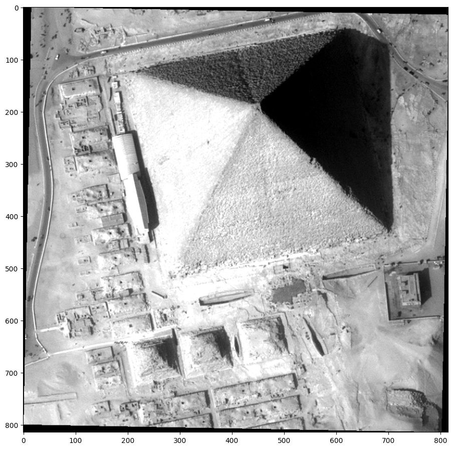

```python
data_image_left = get_full_data(epipolar_image_left, "im")
show_data(data_image_left, mode="image")
```

### Sparse matching: compute sifts

```python
epipolar_matches_left, _ = sparse_matching_application.run(
    epipolar_image_left,
    epipolar_image_right,
    grid_left.attributes["disp_to_alt_ratio"],
    orchestrator=cars_orchestrator
)
```

### Grid correction: correct epipolar grids from sparse matches

Find correction to apply

#### Filter matches

```python
matches_array = sparse_matching_application.filter_matches(
                            epipolar_matches_left,
                            orchestrator=cars_orchestrator)
```

#### Estimate grid correction

```python
(
    grid_correction_coef,
    corrected_matches_array, _, _, _
) = grid_correction.estimate_right_grid_correction(
                    matches_array, grid_right)
```

### Grid correction: correct epipolar grids from sparse matches

Generate new right epipolar grid from correction

#### Correct right grid

```python
corrected_grid_right = grid_correction.correct_grid(
                        grid_right, grid_correction_coef)
```

### Estimate disp min and disp max from sparse matches

```python
dmin, dmax = sparse_matching_tools.compute_disp_min_disp_max(
                    sensor_image_left,
                    sensor_image_right,
                    grid_left,
                    corrected_grid_right,
                    grid_right,
                    corrected_matches_array,
                    orchestrator=cars_orchestrator,
                    disp_margin=(
                        sparse_matching_application.get_disparity_margin()
                    ),
                    disp_to_alt_ratio=grid_left.attributes["disp_to_alt_ratio"],
                    geometry_loader=triangulation_application.get_geometry_loader(),
                    srtm_dir=inputs[sens_cst.INITIAL_ELEVATION],
                    default_alt=inputs[sens_cst.DEFAULT_ALT],
)
```

### Compute margins used in dense matching, with corresponding disparity min and max

```python
(
    dense_matching_margins,
    disp_min,
    disp_max
) = dense_matching_application.get_margins(
            grid_left, disp_min=dmin, disp_max=dmax)
```

### Resampling: generate epipolar images with corrected grids and new margins

```python
(
    new_epipolar_image_left,
    new_epipolar_image_right
) = resampling_application.run(
        sensor_image_left,
        sensor_image_right,
        grid_left,
        corrected_grid_right,
        orchestrator=cars_orchestrator,
        margins=dense_matching_margins,
        optimum_tile_size=(
        dense_matching_application.get_optimal_tile_size(
            disp_min,
            disp_max,
            cars_orchestrator.cluster.checked_conf_cluster[
                "max_ram_per_worker"
            ],
        )
        ),
        add_color=True,
    )
```

### Dense Matching: compute disparities with pandora

```python
epipolar_disparity_map = dense_matching_application.run(
        new_epipolar_image_left,
        new_epipolar_image_right,
        orchestrator=cars_orchestrator,
        disp_min=disp_min,
        disp_max=disp_max,
    )
```

### Dense Matching: compute disparities with pandora

### Show full disparity map

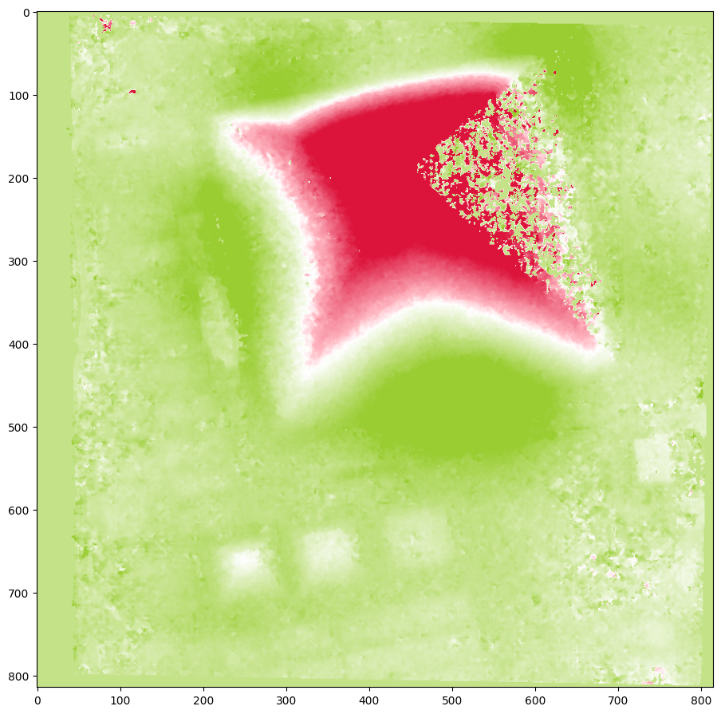

```python
data_disparity = get_full_data(epipolar_disparity_map, "disp")
show_data(data_disparity)
```

### Compute epsg

```python
epsg = preprocessing.compute_epsg(
    sensor_image_left,
    sensor_image_right,
    grid_left,
    corrected_grid_right,
    triangulation_application.get_geometry_loader(),
    orchestrator=cars_orchestrator,
    srtm_dir=inputs[sens_cst.INITIAL_ELEVATION],
    default_alt=inputs[sens_cst.DEFAULT_ALT],
    disp_min=disp_min,
    disp_max=disp_max
)
```

### Triangulation : triangulate matches

```python
epipolar_points_cloud = triangulation_application.run(
        sensor_image_left,
        sensor_image_right,
        new_epipolar_image_left,
        grid_left,
        corrected_grid_right,
        epipolar_disparity_map,
        epsg,
        orchestrator=cars_orchestrator,
        uncorrected_grid_right=grid_right,
        geoid_path=inputs[sens_cst.GEOID],
        disp_min=disp_min,
        disp_max=disp_max,
    )
```

### Compute terrain bounding box

```python
current_terrain_roi_bbox = preprocessing.compute_terrain_bbox(
    inputs[sens_cst.INITIAL_ELEVATION],
    inputs[sens_cst.DEFAULT_ALT],
    inputs[sens_cst.GEOID],
    sensor_image_left,
    sensor_image_right,
    new_epipolar_image_left,
    grid_left,
    corrected_grid_right,
    epsg,
    triangulation_application.get_geometry_loader(),
    resolution=rasterization_application.get_resolution(),
    disp_min=disp_min,
    disp_max=disp_max,
    orchestrator=cars_orchestrator
)
(
    terrain_bounds,
    optimal_terrain_tile_width
) = preprocessing.compute_terrain_bounds(
        [current_terrain_roi_bbox],
        resolution=rasterization_application.get_resolution()
        )
```

### Transform point cloud to terrain point cloud

```python
merged_points_clouds = pc_fusion_application.run(
    [epipolar_points_cloud],
    terrain_bounds,
    epsg,
    orchestrator=cars_orchestrator,
    margins=rasterization_application.get_margins(),
    optimal_terrain_tile_width=optimal_terrain_tile_width
)
```

### Point Cloud Outlier Removing : remove points with small components removing method

```python
(
    filtered_sc_merged_points_clouds
) = pc_outlier_removing_small_comp_application.run(
        merged_points_clouds,
        orchestrator=cars_orchestrator)
```

### Point Cloud Outlier Removing: remove points with statistical removing method

```python
(
    filtered_stats_merged_points_clouds
) = pc_outlier_removing_stats_application.run(
        filtered_sc_merged_points_clouds,
        orchestrator=cars_orchestrator)
```

### Rasterization : rasterize point cloud

```python
dsm = rasterization_application.run(
    filtered_stats_merged_points_clouds,
    epsg,
    orchestrator=cars_orchestrator
)
```

### Show DSM

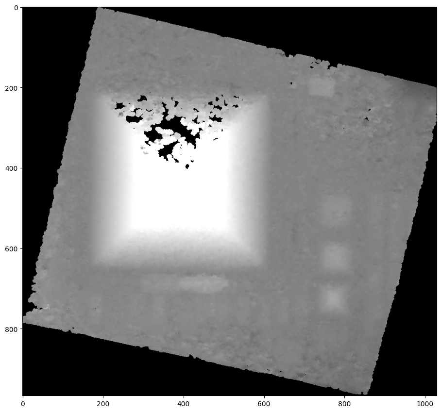

```python
data_dsm = get_full_data(dsm, "hgt")
show_data(data_dsm, mode="dsm")
```

### Show ortho image

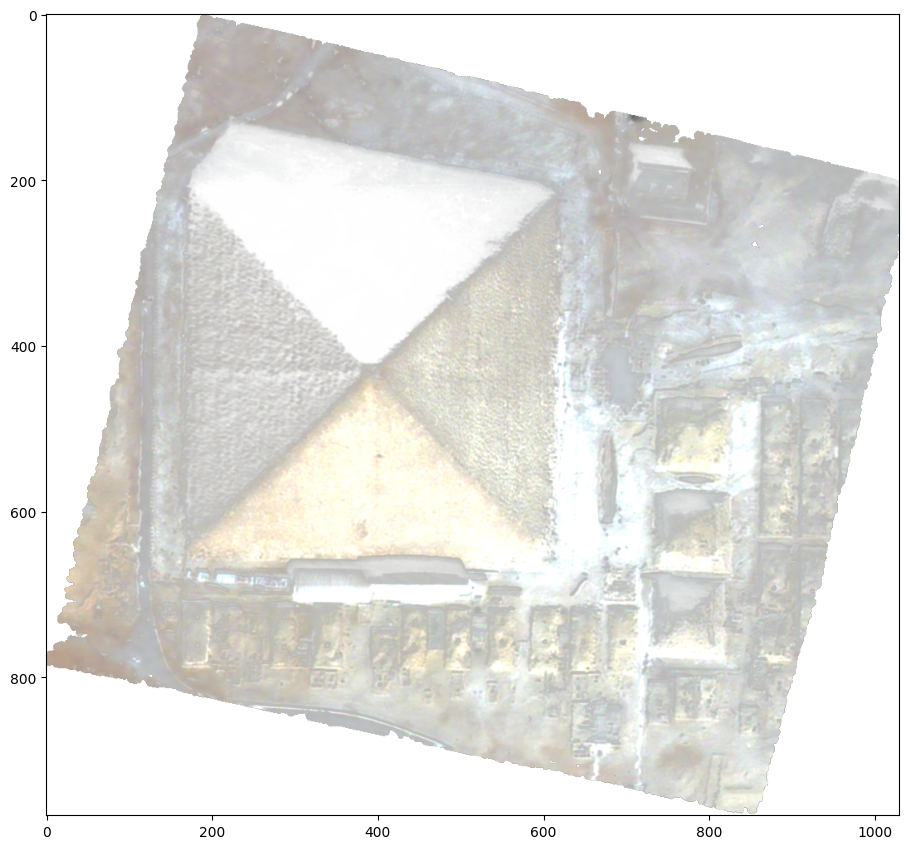

```python
data_ortho = get_full_data(dsm, "img")
show_data(data_ortho, mode='image')
```

### Save DSM

```python
save_data(dsm, os.path.join(output_dir, "dsm.tif"), "hgt")
```

# Thanks for your attention !